# EDA of In-Patient Data for Fraud-detection and Feature engineering

## Introduction

The given dataset contains information on the provider, disease group, referral region and charges and payments for 163,065 hospital-disease group combinations. Based on the paper readings done so far, healthcare fraud can be detected by considering the appropriate unit of analysis and aggregating statistics and ratios across 20 different combinatorial levels. In prior work, we explored the data available to understand possible patterns and to create new features. Here, we extend the analysis, create new features and attempt to cluster the observations.

```python
#Importing packages required for data analysis and plotting
import pandas as pd
import numpy as np
import plotly
import seaborn as sns
import matplotlib.pyplot as plt
```

```python
#Importing the data using pandas
data = pd.read_csv("icdata.csv")
```

```python
#Understanding the data
#Converting necessary columns into numeric floats
data[' Average Total Payments '] = data[' Average Total Payments '].str.extract(r'(\d+.\d)').astype('float')
data[' Average Covered Charges '] = data[' Average Covered Charges '].str.extract(r'(\d+.\d)').astype('float')
data['Average Medicare Payments'] = data['Average Medicare Payments'].str.extract(r'(\d+.\d)').astype('float')
data['Provider Id'] = data['Provider Id'].astype(str)

data.rename(columns = { "DRG Definition": "DRG_def", "Provider Id": "provider_id", "Provider Name": "provider_name", "Provider Street Address": "provider_street",
                       "Provider City": "provider_city", "Provider State": "provider_state", "Provider Zip Code": "provider_zip",
                       "Hospital Referral Region Description": "hospital_referral_region", " Total Discharges ": "total_discharges",
                       " Average Covered Charges ": "average_covered_charges", " Average Total Payments ": "average_total_payments",
                      "Average Medicare Payments": "average_medicare_payments"}, errors = "raise", inplace = True)

#print(data.info())
```

## Feature Engineering

Based on prior explorations, we calculated the following ratios:

- Medicare payments to Total Payments
- Medicare payments to covered charges
- Total payments to covered charges
- Medicare payment/discharge
- Total payment/discharge
- Covered charges/discharge

```python
#Adding additional data columns to enable factor engineering

data['medicare_by_total'] = (data['average_medicare_payments'] / data['average_total_payments'])
data['medicare_by_covered'] = (data['average_medicare_payments'] / data['average_covered_charges'])
data['total_by_covered'] = (data['average_total_payments'] / data['average_covered_charges'])
data['medicare_per_discharge'] = (data['average_medicare_payments'] / data['total_discharges'])
data['total_per_discharge'] = (data['average_total_payments'] / data['total_discharges'])
data['covered_per_discharge'] = (data['average_covered_charges'] / data['total_discharges'])
```

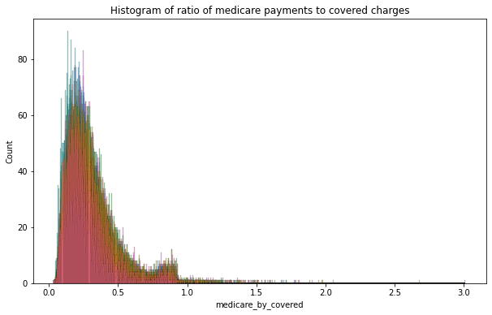

```python
#Exploratory analysis of new variables
plt.figure(figsize = (10,6))
sns.histplot(x = 'medicare_by_covered', hue = 'DRG_def', data = data, legend = False) #, hue = 'DRG_def', legend = False, x_jitter = True, y_jitter = True)
plt.title("Histogram of ratio of medicare payments to covered charges")
```

The ratio of medicare payments to covered charges for a majority of observations fall between 0 and 1. However, a non-zero number of observations have a ratio of average medicare payment to covered charges above 1, and some above 2 as well. Prima facie, this seems suspicious and is worth exploring further. This ratio can therefore serve as an important feature in clustering the observations.

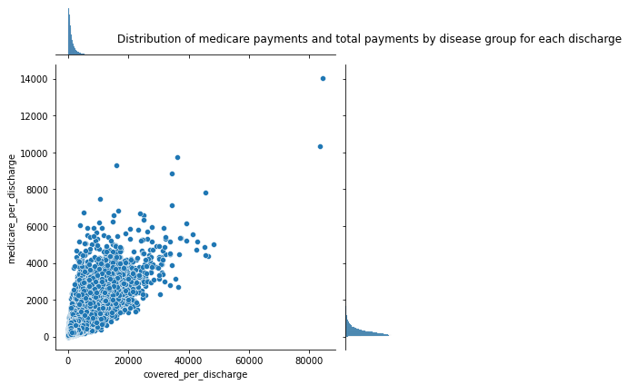

```python
#Exploratory analysis of new variables
plt.figure(figsize = (10,6))
sns.jointplot(y = 'medicare_per_discharge', x = 'covered_per_discharge', data = data, legend = False, x_jitter = True, y_jitter = True)
plt.title("Distribution of medicare payments and total payments by disease group for each discharge", loc = 'center', pad = 25)
```

Ideally, average medicare payments must be lower than or equal to average coverage. This would mean on a scatterplot, they would be on or below the diagonal. However, as can be seen from this graph, the observations are widely distributed. However, the count of observation with atypical values are very low as seen from the histogram!This hints at these two variables and their ratio being useful features.

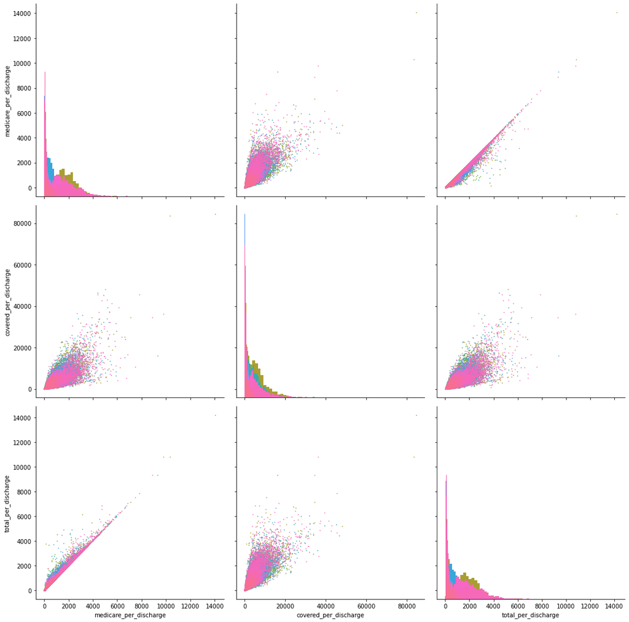

```python
p1 = sns.PairGrid(data[['medicare_per_discharge', 'covered_per_discharge', 'total_per_discharge', 'DRG_def']],
             hue='DRG_def',
             height = 5)
p1.map_diag(plt.hist, bins = 60)
p1.map_offdiag(plt.scatter, s=0.5)
```

As we can see from the plots above, the distrbutions are more tightly clustered for the new variables, with some obvious anomalies visible. This indicates that these variables can provide information for clustering our observations into categories which can be examined further.

Further we calculated the following summary statistics:

- Median
- Standard Deviation

Across the following groupings:

- Provider, state and disease group
- disease group by state, disease group by referral group

```python
##### BASE LEVEL summaries for provider, state and disease groups
data_provider_stat1 = data[['provider_id', 'total_discharges', 'average_covered_charges', 'average_total_payments', 'average_medicare_payments',
                          'total_per_discharge']].groupby('provider_id').median()
data_provider_stat1.rename(columns = {'provider_id': 'provider_id', 'total_discharges' : 'median_provider_td', 'average_covered_charges': 'median_provider_cc',
                                      'average_total_payments': 'median_provider_tp', 'average_medicare_payments': 'median_provider_mp',
                                      'total_per_discharge': 'median_provider_tpd'}, inplace = True)

data_state_stat1 = data[['provider_state', 'total_discharges', 'average_covered_charges', 'average_total_payments', 'average_medicare_payments',
                          'total_per_discharge']].groupby('provider_state').median()
data_state_stat1.rename(columns = {'provider_state': 'provider_state', 'total_discharges' : 'median_state_td', 'average_covered_charges': 'median_state_cc',
                                      'average_total_payments': 'median_state_tp', 'average_medicare_payments': 'median_state_mp',
                                      'total_per_discharge': 'median_state_tpd'}, inplace = True)

data_drg_stat1 = data[['DRG_def', 'total_discharges', 'average_covered_charges', 'average_total_payments', 'average_medicare_payments',
                          'total_per_discharge']].groupby('DRG_def').median()
data_drg_stat1.rename(columns = {'DRG_def': 'DRG_def', 'total_discharges' : 'median_drg_td', 'average_covered_charges': 'median_drg_cc',
                                      'average_total_payments': 'median_drg_tp', 'average_medicare_payments': 'median_drg_mp',
                                      'total_per_discharge': 'median_drg_tpd'}, inplace = True)

data_provider_stat2 = data[['provider_id', 'total_discharges', 'average_covered_charges', 'average_total_payments', 'average_medicare_payments',
                          'total_per_discharge']].groupby('provider_id').std()
data_provider_stat2.rename(columns = {'provider_id': 'provider_id', 'total_discharges' : 'sd_provider_td', 'average_covered_charges': 'sd_provider_cc',
                                      'average_total_payments': 'sd_provider_tp', 'average_medicare_payments': 'sd_provider_mp',
                                      'total_per_discharge': 'sd_provider_tpd'}, inplace = True)

data_state_stat2 = data[['provider_state', 'total_discharges', 'average_covered_charges', 'average_total_payments', 'average_medicare_payments',
                          'total_per_discharge']].groupby('provider_state').std()
data_state_stat2.rename(columns = {'provider_state': 'provider_state', 'total_discharges' : 'sd_state_td', 'average_covered_charges': 'sd_state_cc',
                                      'average_total_payments': 'sd_state_tp', 'average_medicare_payments': 'sd_state_mp',
                                      'total_per_discharge': 'sd_state_tpd'}, inplace = True)

data_drg_stat2 = data[['DRG_def', 'total_discharges', 'average_covered_charges', 'average_total_payments', 'average_medicare_payments',
                          'total_per_discharge']].groupby('DRG_def').std()
data_drg_stat2.rename(columns = {'DRG_def': 'DRG_def', 'total_discharges' : 'sd_drg_td', 'average_covered_charges': 'sd_drg_cc',
                                      'average_total_payments': 'sd_drg_tp', 'average_medicare_payments': 'sd_drg_mp',
                                      'total_per_discharge': 'sd_drg_tpd'}, inplace = True)

###### level 1:   disease group X state

data_drg_state_stat1 = data[['DRG_def', 'provider_state', 'total_discharges', 'average_covered_charges', 'average_total_payments', 'average_medicare_payments',
                          'total_per_discharge']].groupby(['DRG_def', 'provider_state']).median()
data_drg_state_stat1.rename(columns = {'DRG_def': 'DRG_def', 'provider_state': 'provider_state', 'total_discharges' : 'median_drg_state_td', 'average_covered_charges': 'median_drg_state_cc',
                                      'average_total_payments': 'median_drg_state_tp', 'average_medicare_payments': 'median_drg_state_mp',
                                      'total_per_discharge': 'median_drg_state_tpd'}, inplace = True)

data_drg_state_stat2 = data[['DRG_def', 'provider_state', 'total_discharges', 'average_covered_charges', 'average_total_payments', 'average_medicare_payments',
                          'total_per_discharge']].groupby(['DRG_def', 'provider_state']).std()
data_drg_state_stat2.rename(columns = {'DRG_def': 'DRG_def', 'provider_state': 'provider_state', 'total_discharges' : 'sd_drg_state_td', 'average_covered_charges': 'sd_drg_state_cc',
                                      'average_total_payments': 'sd_drg_state_tp', 'average_medicare_payments': 'sd_drg_state_mp',
                                      'total_per_discharge': 'sd_drg_state_tpd'}, inplace = True)

###### level 1: disease group X referral group

data_drg_rfg_stat1 = data[['DRG_def', 'hospital_referral_region', 'total_discharges', 'average_covered_charges', 'average_total_payments', 'average_medicare_payments',
                           'total_per_discharge']].groupby(['DRG_def', 'hospital_referral_region']).median()
data_drg_rfg_stat1.rename(columns = {'DRG_def': 'DRG_def', 'hospital_referral_region': 'hospital_referral_region', 'total_discharges' : 'median_drg_rfg_td', 'average_covered_charges': 'median_drg_rfg_cc',
                                      'average_total_payments': 'median_drg_rfg_tp', 'average_medicare_payments': 'median_drg_rfg_mp',
                                      'total_per_discharge': 'median_drg_rfg_tpd'}, inplace = True)

data_drg_rfg_stat2 = data[['DRG_def', 'hospital_referral_region', 'total_discharges', 'average_covered_charges', 'average_total_payments', 'average_medicare_payments',
                          'total_per_discharge']].groupby(['DRG_def', 'hospital_referral_region']).std()
data_drg_rfg_stat2.rename(columns = {'DRG_def': 'DRG_def', 'hospital_referral_region': 'hospital_referral_region', 'total_discharges' : 'sd_drg_rfg_td', 'average_covered_charges': 'sd_drg_rfg_cc',
                                      'average_total_payments': 'sd_drg_rfg_tp', 'average_medicare_payments': 'sd_drg_rfg_mp',
                                      'total_per_discharge': 'sd_drg_rfg_tpd'}, inplace = True)
```

```python
####### Combining with the main data frame

### Base level combination
data = data.merge(data_provider_stat1, on = 'provider_id', how = 'left')
data = data.merge(data_provider_stat2, on = 'provider_id', how = 'left')

data = data.merge(data_state_stat1, on = 'provider_state', how = 'left')
data = data.merge(data_state_stat2, on = 'provider_state', how = 'left')

data = data.merge(data_drg_stat1, on = 'DRG_def', how = 'left')
data = data.merge(data_drg_stat2, on = 'DRG_def', how = 'left')

#level 1 - drg X state
data = pd.merge(data, data_drg_state_stat1, left_on = ['DRG_def', 'provider_state'], right_on = ['DRG_def', 'provider_state'])
data = pd.merge(data, data_drg_state_stat2, left_on = ['DRG_def', 'provider_state'], right_on = ['DRG_def', 'provider_state'])

#level 1 - drg X referral group
data = pd.merge(data, data_drg_rfg_stat1, left_on = ['DRG_def', 'hospital_referral_region'], right_on = ['DRG_def', 'hospital_referral_region'])
data = pd.merge(data, data_drg_rfg_stat2, left_on = ['DRG_def', 'hospital_referral_region'], right_on = ['DRG_def', 'hospital_referral_region'])
```

```python
#Creating deviation measures ( abs(value - mean)/std deviation)
#deviation measure for provider mean and drg and state median
data['dev_provider_cc'] = (data['average_covered_charges'] - data['median_provider_cc'])/data['sd_provider_cc']
data['dev_provider_tp'] = (data['average_total_payments'] - data['median_provider_tp'])/data['sd_provider_tp']
data['dev_provider_mp'] = (data['average_medicare_payments'] - data['median_provider_mp'])/data['sd_provider_mp']
data['dev_provider_td'] = (data['total_discharges'] - data['median_provider_td'])/data['sd_provider_td']
data['dev_provider_tpd']= (data['total_per_discharge'] - data['median_provider_tpd']) / data['sd_provider_tpd']

data['dev_drg_cc'] = (data['average_covered_charges'] - data['median_drg_cc'])/data['sd_drg_cc']
data['dev_drg_tp'] = (data['average_total_payments'] - data['median_drg_tp'])/data['sd_drg_tp']
data['dev_drg_mp'] = (data['average_medicare_payments'] - data['median_drg_mp'])/data['sd_drg_mp']
data['dev_drg_td'] = (data['total_discharges'] - data['median_drg_td'])/data['sd_drg_td']
data['dev_drg_tpd']= (data['total_per_discharge'] - data['median_drg_tpd']) / data['sd_drg_tpd']

data['dev_state_cc'] = (data['average_covered_charges'] - data['median_state_cc'])/data['sd_state_cc']
data['dev_state_tp'] = (data['average_total_payments'] - data['median_state_tp'])/data['sd_state_tp']
data['dev_state_mp'] = (data['average_medicare_payments'] - data['median_state_mp'])/data['sd_state_mp']
data['dev_state_cc'] = (data['total_discharges'] - data['median_state_td'])/data['sd_state_td']
data['dev_state_tpd']= (data['total_per_discharge'] - data['median_state_tpd']) / data['sd_state_tpd']

#deviation measure for drg and state
data['dev_drg_state_cc'] = (data['average_covered_charges'] - data['median_drg_state_cc'] )/data['sd_drg_state_cc']
data['dev_drg_state_tp'] = (data['average_total_payments'] - data['median_drg_state_tp'])/data['sd_drg_state_tp']
data['dev_drg_state_mp'] = (data['average_medicare_payments'] - data['median_drg_state_mp'])/data['sd_drg_state_mp']
data['dev_drg_state_td'] = (data['total_discharges'] - data['median_drg_state_td'])/data['sd_drg_state_td']
data['dev_drg_state_tpd']= (data['total_per_discharge'] - data['median_drg_state_tpd']) / data['sd_drg_state_tpd']

#deviation measure for drg and hospital referral group
data['dev_drg_rfg_cc'] = (data['average_covered_charges'] - data['median_drg_rfg_cc']) / data['sd_drg_rfg_cc']
data['dev_drg_rfg_tp'] = (data['average_total_payments'] - data['median_drg_rfg_tp'])/data['sd_drg_rfg_tp']
data['dev_drg_rfg_mp'] = (data['average_medicare_payments'] - data['median_drg_rfg_mp'])/data['sd_drg_rfg_mp']
data['dev_drg_rfg_td'] = (data['total_discharges'] - data['median_drg_rfg_td'])/data['sd_drg_rfg_td']
data['dev_drg_rfg_tpd']= (data['total_per_discharge'] - data['median_drg_rfg_tpd']) / data['sd_drg_rfg_tpd']
```

- Covered charges
- Total Payments
- Medicare Payments
- Total Discharges
- Total payment per discharge

For each of these, we have deviations from mean at the level of :

- Provider
- Disease Group
- State
- Disease group by each state
- Disease group by each hospital referral region

## Further Future Analysis: Clustering Observations based on available data

As a final exercise, we will attempt to cluster these observations on the basis of the available data. This serves two purposes:

1. Reducing the number of observations which need to be examined manually
2. Provide a model for identifying fraudulent transaction as they happen

```python
#Cleanin up data for modelling by removing factors and null values
drop_vars = data.iloc[:, 18:68].columns.tolist()
#Creating index of columns with null values
null_col = data.isnull().sum().sort_values(ascending = False)
null_col = null_col[ null_col > 0]
#Looping through to replace NAs with mean values
null_col = null_col.index
for col in null_col:
  data.loc[:, col].fillna(data.loc[:, col].mean(), inplace = True)
```

```python
#Loading required packages
from sklearn.cluster import KMeans
from sklearn.preprocessing import StandardScaler
from sklearn.metrics import silhouette_score
```

To enable easier modelling with K-means, we use one-hot encoding for Disease groups, referral regions, states and providers. To be able to create the model without overloading our system, we limit levels to 26 for each of these variables

```python
#Recategorizing variables to enable one hot encoding
drg_levels = data['DRG_def'].value_counts().nlargest(25).index.tolist()
data['new_drg'] = data['DRG_def'].apply(lambda x: x if x in drg_levels else 'other')
hrr_levels = data['hospital_referral_region'].value_counts(normalize = True).nlargest(25).index.tolist()
data['new_hrr'] = data['hospital_referral_region'].apply(lambda x: x if x in hrr_levels else 'other')
state_levels = data['provider_state'].value_counts(normalize = True).nlargest(25).index.tolist()
data['new_state'] = data['provider_state'].apply(lambda x: x if x in state_levels else 'other')
pid_levels = data['provider_id'].value_counts(normalize = True).nlargest(25).index.tolist()
data['new_pid'] = data['provider_id'].apply(lambda x: x if x in pid_levels else 'other')
```

```python
dummy_drg = pd.get_dummies(data['new_drg'], dummy_na=False, drop_first= True)
dummy_state = pd.get_dummies(data['new_state'], dummy_na=False, drop_first= True)
dummy_hrr = pd.get_dummies(data['new_hrr'], dummy_na=False, drop_first= True)
dummy_pid = pd.get_dummies(data['new_pid'], dummy_na=False, drop_first= True)
#dummy_drg.head()
#dummy_state.head()
#dummy_hrr.head()
```

```python
#preparing the data
#Copying data into new df
data_model = data.copy()
data_model = pd.concat([data_model, dummy_drg], axis = 1)
data_model = pd.concat([data_model, dummy_state], axis = 1)
data_model = pd.concat([data_model, dummy_hrr], axis = 1)
data_model = pd.concat([data_model, dummy_pid], axis = 1)
#Removing factor data
drop_cols = ['DRG_def', 'provider_id', 'provider_name', 'provider_street', 'provider_city', 'provider_state', 'provider_zip', 'hospital_referral_region', 'new_hrr', 'new_drg', 'new_state', 'new_pid']
data_model = data_model.drop(drop_cols, axis = 1)
data_model = data_model.drop(drop_vars, axis = 1)
data_model.info()
```

```
<class 'pandas.core.frame.DataFrame'>
Int64Index: 163065 entries, 0 to 163064
Columns: 134 entries, total_discharges to other
dtypes: float64(33), int64(1), uint8(100)
memory usage: 59.1 MB
```

```python
#Standardizing all values
scaler = StandardScaler()
data_model = scaler.fit_transform(data_model)
```

```python
#Preparing the model
#Identifying best set of clusters
sse = []

for n in range(2,11):
  kmeans = KMeans(n_clusters = n, random_state= 257)
  kmeans.fit(data_model)
  sse.append(kmeans.inertia_)
```

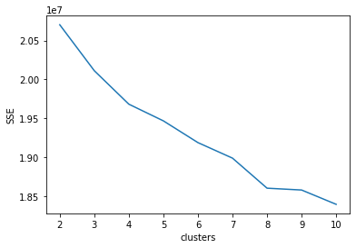

```python
model_sse = pd.DataFrame(data = { 'clusters' : range(2,11), 'SSE' : sse})

sns.lineplot(x = 'clusters', y = 'SSE', data = model_sse)
```

```python
#Building a 6 cluster model
kmm = KMeans(n_clusters = 6, random_state= 257)
kmm.fit(data_model)
```

```
KMeans(algorithm='auto', copy_x=True, init='k-means++', max_iter=300,
       n_clusters=6, n_init=10, n_jobs=None, precompute_distances='auto',
       random_state=257, tol=0.0001, verbose=0)
```

```python
#adding the labels to the dataset
data_check = data.copy()
data_check = data_check.drop(drop_vars, axis = 1)
data_check['label'] = kmm.labels_

#summarizing values by label
data_check.groupby('label').median().sort_values(by = 'average_total_payments', ascending = False)
```

| label | provider_zip | total_discharges | average_covered_charges | average_total_payments | average_medicare_payments | medicare_by_total | medicare_by_covered | total_by_covered | medicare_per_discharge | total_per_discharge | covered_per_discharge | dev_provider_cc | dev_provider_tp | dev_provider_mp | dev_provider_td | dev_provider_tpd | dev_drg_cc | dev_drg_tp | dev_drg_mp | dev_drg_td | dev_drg_tpd | dev_state_cc | dev_state_tp | dev_state_mp | dev_state_tpd | dev_drg_state_cc | dev_drg_state_tp | dev_drg_state_mp | dev_drg_state_td | … |
| --- | --- | --- | --- | --- | --- | --- | --- | --- | --- | --- | --- | --- | --- | --- | --- | --- | --- | --- | --- | --- | --- | --- | --- | --- | --- | --- | --- | --- | --- | --- |
| 4 | 46060 | 18 | 118275.80 | 34714.00 | 32350.60 | 0.963890 | 0.273114 | 0.294920 | 1665.600000 | 1815.023810 | 6086.423529 | 3.529893 | 3.833591 | 3.862746 | -0.247419 | 3.305919 | 0.147878 | 0.222758 | 0.211442 | -0.173649 | 0.374845 | -0.174066 | 3.760680 | 3.793184 | 3.325517 | 0.143738 | 0.183997 | 0.183050 | -0.138122 | … |
| 1 | 47130 | 19 | 48791.70 | 12546.00 | 11180.30 | 0.922388 | 0.243036 | 0.270996 | 567.038462 | 633.120000 | 2332.356522 | 1.042124 | 0.973627 | 0.979354 | -0.181145 | 0.925954 | 0.051215 | -0.077365 | -0.047997 | -0.247159 | 0.368631 | -0.148548 | 0.745969 | 0.749479 | 0.805812 | 0.000000 | -0.061201 | -0.027712 | -0.231114 | … |
| 0 | 39216 | 24 | 25603.40 | 9689.10 | 8605.60 | 0.902770 | 0.339872 | 0.389389 | 359.300000 | 412.648508 | 1043.765934 | -0.017081 | -0.013106 | -0.021452 | -0.048655 | 0.026148 | 0.181234 | 1.852675 | 1.909342 | -0.149970 | 0.937022 | -0.066359 | 0.234831 | 0.237727 | 0.252533 | 0.291269 | 1.763264 | 1.838083 | -0.168350 | … |
| 2 | 8084 | 37 | 50084.75 | 7298.75 | 6260.35 | 0.869140 | 0.124465 | 0.144589 | 169.948684 | 209.038333 | 1370.333871 | -0.008862 | -0.005658 | -0.010685 | 0.000000 | -0.004374 | 1.783338 | 0.060468 | 0.075961 | 0.527826 | -0.423892 | 0.071311 | -0.080655 | -0.095074 | -0.078155 | -0.016986 | -0.551722 | -0.565203 | 0.121478 | … |
| 5 | 43222 | 79 | 26635.70 | 7171.90 | 6088.70 | 0.849975 | 0.232663 | 0.279306 | 76.917391 | 91.900000 | 334.856303 | -0.043107 | -0.043760 | -0.032310 | 0.986708 | -0.321806 | 0.133387 | 0.091213 | 0.068505 | 1.272704 | -0.637394 | 1.069661 | -0.000050 | -0.004850 | -0.392124 | 0.168793 | 0.103294 | 0.074874 | 1.376448 | … |
| 3 | 45236 | 23 | 17982.95 | 5453.90 | 4422.55 | 0.819778 | 0.245684 | 0.307018 | 196.444058 | 245.039011 | 787.122596 | -0.190779 | -0.208379 | -0.216576 | -0.048144 | -0.046552 | -0.145036 | -0.193751 | -0.180598 | -0.156101 | 0.126224 | -0.081053 | -0.230881 | -0.242014 | -0.053518 | -0.160085 | -0.184906 | -0.185917 | -0.139465 | … |

```python
data_check['label'].value_counts(normalize = True) * 100
```

```
3    43.609604
5    21.344249
1    18.341766
0    11.592923
4     4.084874
2     1.026584
Name: label, dtype: float64
```

```python
data_check[['DRG_def', 'label']].groupby('label').nunique()
```

| label | DRG_def |
| --- | --- |
| 0 | 96 |
| 1 | 79 |
| 2 | 100 |
| 3 | 89 |
| 4 | 32 |
| 5 | 99 |

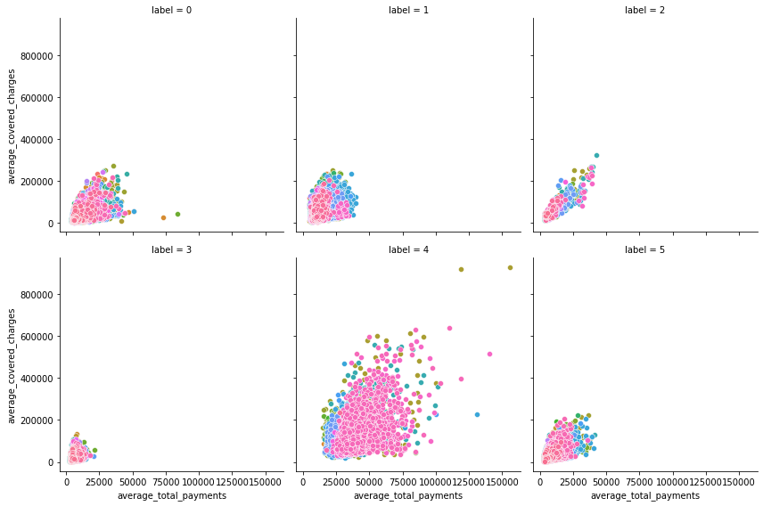

```python
g = sns.FacetGrid(data_check, col = 'label', hue = 'DRG_def', col_wrap = 3, height = 4)
g.map(sns.scatterplot, 'average_total_payments', 'average_covered_charges')
```

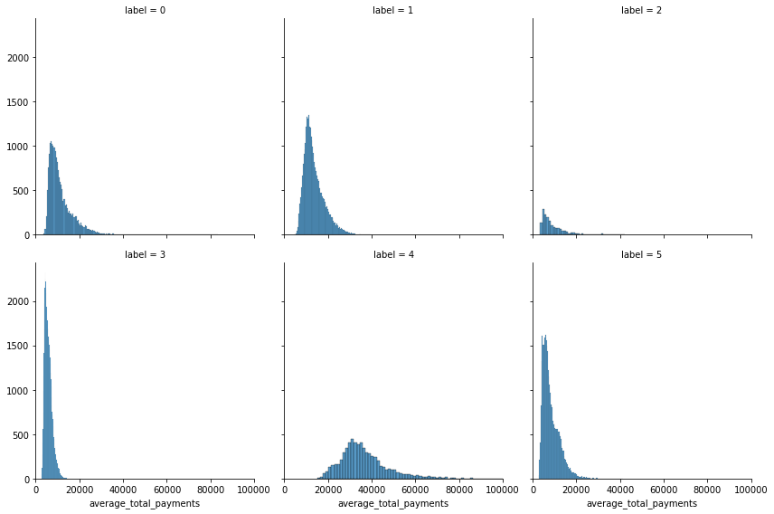

```python
g = sns.FacetGrid(data_check, col = 'label', col_wrap = 3, height = 4, xlim = (0, 100000))
g.map(sns.histplot, 'average_total_payments')
```

Similarly, while all clusters see peaks towards lower values, cluster 4 is peaking in the midrange with two peaks!

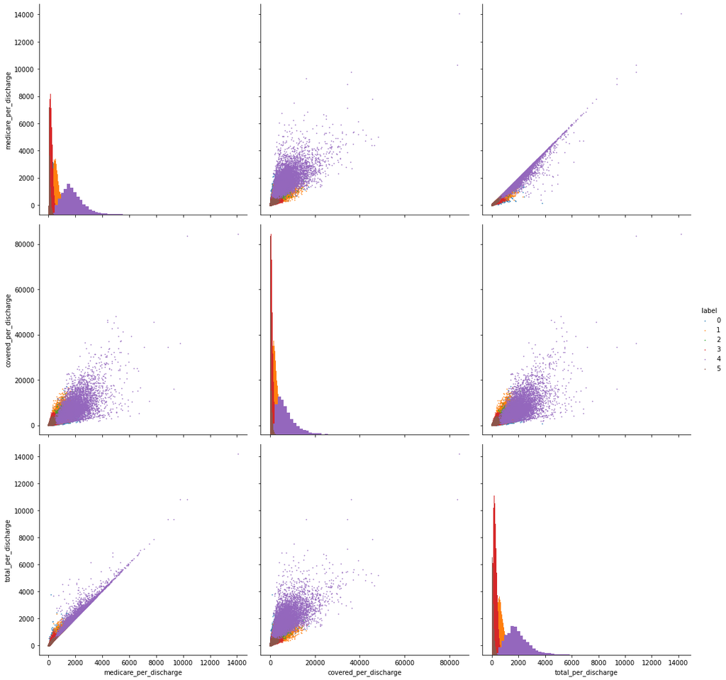

```python
p1 = sns.PairGrid(data_check[['medicare_per_discharge', 'covered_per_discharge', 'total_per_discharge', 'label']],
             hue='label',
             height = 5)
p1.map_diag(plt.hist, bins = 60)
p1.map_offdiag(plt.scatter, s=0.5)
p1.add_legend()
```

By plotting the values per discharge for medicare payments, total payments and covered charges, we can clearly see how cluster 4 (purple) is vastly different and higher than the other groups.

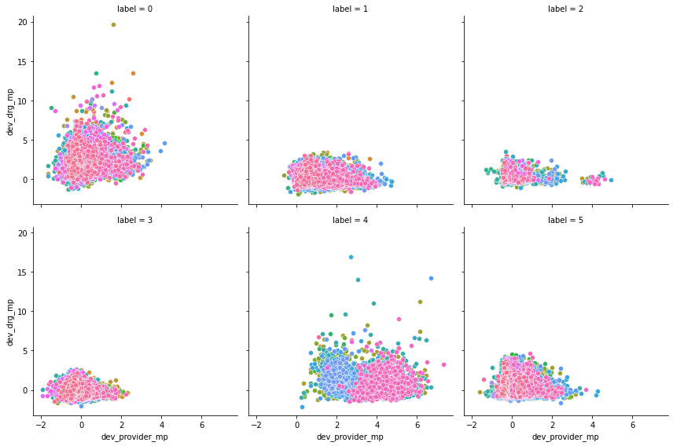

```python
g = sns.FacetGrid(data_check, col = 'label', hue = 'DRG_def', col_wrap = 3, height = 4)
g.map(sns.scatterplot, 'dev_provider_mp', 'dev_drg_mp')
```

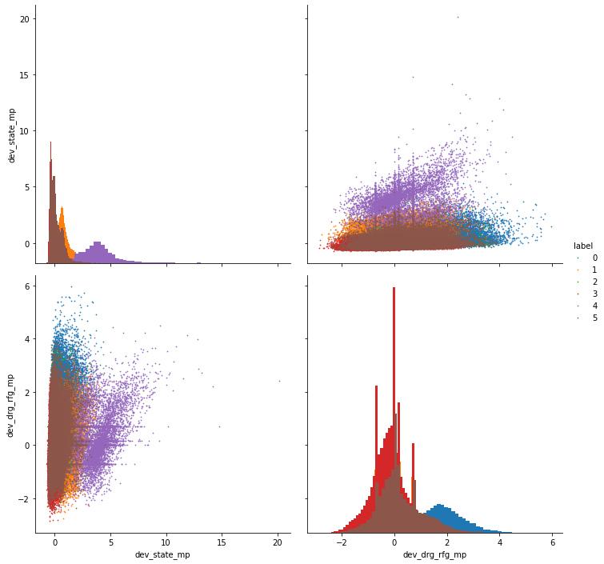

```python
p1 = sns.PairGrid(data_check[['dev_state_mp', 'dev_drg_rfg_mp', 'label']],
             hue='label',
             height = 5)
p1.map_diag(plt.hist, bins = 60)
p1.map_offdiag(plt.scatter, s=0.5)
p1.add_legend()
```

## Principal Component Analysis

We use a 2 component PCA to visually estimate how divergent the different clusters are.

```python
#Attempting PCA analysis
x = data_model.copy()
y = kmm.labels_
```

```python
from sklearn. decomposition import PCA
pca = PCA(n_components = 2)

principalComponents = pca.fit_transform(x)
principalDf = pd.DataFrame(data = principalComponents
             , columns = ['principal component 1', 'principal component 2'])
finalDf = pd.concat([principalDf, data_check['label']], axis = 1)
```

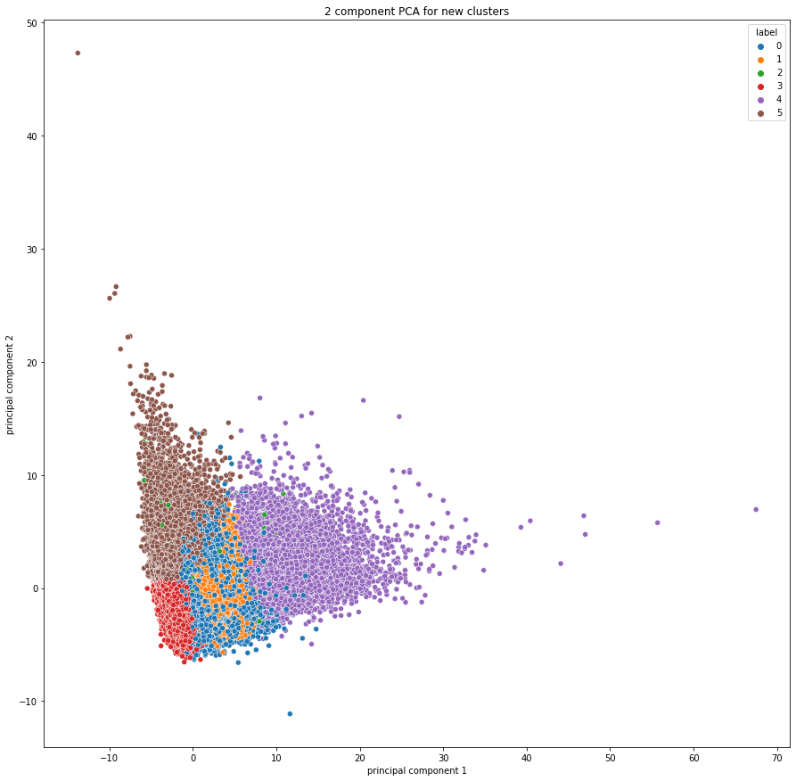

```python
plt.figure(figsize = (15,15))
sns.color_palette('tab10')
sns.scatterplot(x = 'principal component 1', y = 'principal component 2', hue = 'label', data = finalDf, palette='tab10')
plt.title("2 component PCA for new clusters", loc = 'center')
```